# HW5-3_Bonus_TaylorSwift

Group5

October 26, 2015

Theme: 泰勒斯真的靠失戀在賺錢嗎！？ Background: 泰勒斯2008 “Fearless” 專輯 - 近870萬銷售量 泰勒斯2010 “Speak now” 專輯 - 500萬銷售量 Hypothesis：泰勒斯最佳銷售唱片“Fearless”在全球有近870萬銷量, 但緊接著釋出的專輯“Speak  
now”卻只有500萬銷售量, 小道消息指出, 泰勒斯源源不絕的靈感皆來自於戀愛, 尤其是失戀,  
因此想進一步的探討歌詞間和銷售量的關聯性, 以及失戀與銷售量是否呈正相關。

```r
##先把原始檔用linux整理一次，原始檔是手動從網路上複製貼上到txt的
#cat fearless_lyrics.txt | tr -d '[:punct:]' | tr '[A-Z]' '[a-z]' | tr -d '[:digit:]' | tr ' ' '\n' > fearless_forR.txt

path <- "http://homepage.ntu.edu.tw/~b04106003/file/speaknow_forR.txt"
text <- read.csv(path,encoding="UTF-8")
head <- as.vector(unique(text[,1]))
result <- matrix(0,length(head),2)
result <- as.data.frame(result)
col_name <- c('word','frequent')
colnames(result) <- col_name
for(i in 1:length(head)){
    result[i,1] <- head[i]
}
for(i in 1:nrow(text)){
    if(text[i,1]=='' || is.na(text[i,1])){
    }
    else{
        for(ii in 1:nrow(result)){
            if(text[i,1]==result[ii,1]){
                result[ii,2] <- as.numeric(result[ii,2]) + 1
            }
        }
    }
}
order_index <- rev(order(result[,2]))
frequent <- as.data.frame(result)
for(i in 1:length(order_index)){
    row_index <- order_index[i]
    frequent[i,2] = result[row_index,2]
    frequent[i,1] = result[row_index,1]
}
write.csv(frequent,'fearless.csv')
f_freq <- frequent
```

Step 2: get speaknow_lyrics_file

```r
##先把原始檔用linux整理一次，原始檔是手動從網路上複製貼上到txt的
#cat speaknow_lyrics.txt | tr -d '[:punct:]' | tr '[A-Z]' '[a-z]' | tr -d '[:digit:]' | tr ' ' '\n' > speaknow_forR.txt
path <- "http://homepage.ntu.edu.tw/~b04106003/file/speaknow_forR.txt"
text <- read.csv(path,encoding="UTF-8")
head <- as.vector(unique(text[,1]))
result <- matrix(0,length(head),2)
result <- as.data.frame(result)
col_name <- c('word','frequent')
colnames(result) <- col_name
for(i in 1:length(head)){
    result[i,1] <- head[i]
}
for(i in 1:nrow(text)){
    if(text[i,1]=='' || is.na(text[i,1])){
    }
    else{
        for(ii in 1:nrow(result)){
            if(text[i,1]==result[ii,1]){
                result[ii,2] <- as.numeric(result[ii,2]) + 1
            }
        }
    }
}
order_index <- rev(order(result[,2]))
frequent <- as.data.frame(result)
for(i in 1:length(order_index)){
    row_index <- order_index[i]
    frequent[i,2] = result[row_index,2]
    frequent[i,1] = result[row_index,1]
}

write.csv(frequent,'speaknow.csv')
s_freq <- frequent
```

```r
library(data.table)
head(f_freq,10)
```

[output not shown]

[figure not shown]

```r
f_dt <- as.data.table(f_freq)
barplot(
  head(f_dt[,frequent],10),
  names.arg = head(f_dt[,word],10),
  xlab = "top 10 words",
  ylab = "frequency",
  main = "Top 10 words with the highest frequency in Fearless",
  las = 1
)
```

```r
head(s_freq,10)
```

```
##    word frequent
## 1   you      352
## 2     i      253
## 3   the      248
## 4   and      187
## 5    to      121
## 6    me      111
## 7     a       98
## 8  your       92
## 9    on       82
## 10   it       81
```

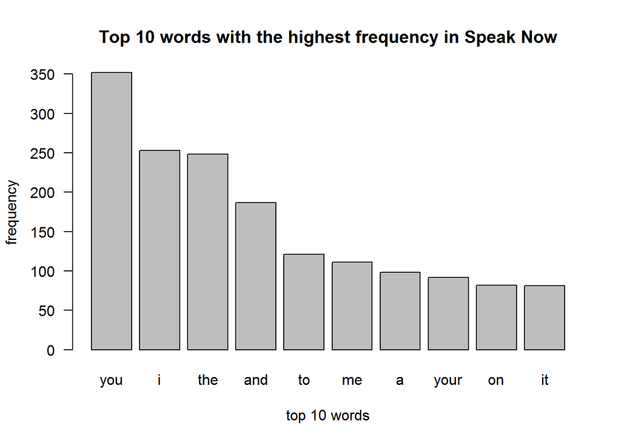

```r
s_dt <- as.data.table(s_freq)
barplot(
  head(s_dt[,frequent],10),
  names.arg = head(s_dt[,word],10),
  xlab = "top 10 words",
  ylab = "frequency",
  main = "Top 10 words with the highest frequency in Speak Now",
  las = 1
)
```